# Prosper Loan Data Exploration

## Preliminary Wrangling

> This data set contains 113,937 loans with 81 variables on each loan, including loan amount, borrower rate (or interest rate), current loan status, borrower income, and many others.

```python
# import all packages and set plots to be embedded inline
import numpy as np
import pandas as pd
import matplotlib.pyplot as plt
import seaborn as sb

%matplotlib inline
```

```python
loans = pd.read_csv('prosperLoanData.csv')
```

```python
print(loans.shape)
print(loans.dtypes)
loans.head(7)
```

```
(113937, 81)
ListingKey                      object
ListingNumber                    int64
ListingCreationDate             object
CreditGrade                     object
Term                             int64
                                ...
PercentFunded                  float64
Recommendations                  int64
InvestmentFromFriendsCount       int64
InvestmentFromFriendsAmount    float64
Investors                        int64
Length: 81, dtype: object
```

|  | ListingKey | ListingNumber | ListingCreationDate | CreditGrade | Term | LoanStatus | ClosedDate | BorrowerAPR | BorrowerRate | LenderYield | ... | LP_ServiceFees | LP_CollectionFees | LP_GrossPrincipalLoss | LP_NetPrincipalLoss | LP_NonPrincipalRecoverypayments | PercentFunded | Recommendations | InvestmentFromFriendsCount | InvestmentFromFriendsAmount | Investors |
| --- | --- | --- | --- | --- | --- | --- | --- | --- | --- | --- | --- | --- | --- | --- | --- | --- | --- | --- | --- | --- | --- |
| 0 | 1021339766868145413AB3B | 193129 | 2007-08-26 19:09:29.263000000 | C | 36 | Completed | 2009-08-14 00:00:00 | 0.16516 | 0.1580 | 0.1380 | ... | -133.18 | 0.0 | 0.0 | 0.0 | 0.0 | 1.0 | 0 | 0 | 0.0 | 258 |
| 1 | 10273602499503308B223C1 | 1209647 | 2014-02-27 08:28:07.900000000 | NaN | 36 | Current | NaN | 0.12016 | 0.0920 | 0.0820 | ... | 0.00 | 0.0 | 0.0 | 0.0 | 0.0 | 1.0 | 0 | 0 | 0.0 | 1 |
| 2 | 0EE9337825851032864889A | 81716 | 2007-01-05 15:00:47.090000000 | HR | 36 | Completed | 2009-12-17 00:00:00 | 0.28269 | 0.2750 | 0.2400 | ... | -24.20 | 0.0 | 0.0 | 0.0 | 0.0 | 1.0 | 0 | 0 | 0.0 | 41 |
| 3 | 0EF5356002482715299901A | 658116 | 2012-10-22 11:02:35.010000000 | NaN | 36 | Current | NaN | 0.12528 | 0.0974 | 0.0874 | ... | -108.01 | 0.0 | 0.0 | 0.0 | 0.0 | 1.0 | 0 | 0 | 0.0 | 158 |
| 4 | 0F023589499656230C5E3E2 | 909464 | 2013-09-14 18:38:39.097000000 | NaN | 36 | Current | NaN | 0.24614 | 0.2085 | 0.1985 | ... | -60.27 | 0.0 | 0.0 | 0.0 | 0.0 | 1.0 | 0 | 0 | 0.0 | 20 |
| 5 | 0F05359734824199381F61D | 1074836 | 2013-12-14 08:26:37.093000000 | NaN | 60 | Current | NaN | 0.15425 | 0.1314 | 0.1214 | ... | -25.33 | 0.0 | 0.0 | 0.0 | 0.0 | 1.0 | 0 | 0 | 0.0 | 1 |
| 6 | 0F0A3576754255009D63151 | 750899 | 2013-04-12 09:52:56.147000000 | NaN | 36 | Current | NaN | 0.31032 | 0.2712 | 0.2612 | ... | -22.95 | 0.0 | 0.0 | 0.0 | 0.0 | 1.0 | 0 | 0 | 0.0 | 1 |

7 rows × 81 columns

```python
# Consider only a subset of the features
cols = ['Term', 'LoanStatus', 'BorrowerAPR', 'ProsperRating (Alpha)', 'ProsperScore', 'Occupation',
        'ListingCategory (numeric)', 'EmploymentStatus', 'StatedMonthlyIncome', 'LoanOriginalAmount', 'MonthlyLoanPayment']
loans = loans[cols]
loans.head()
```

|  | Term | LoanStatus | BorrowerAPR | ProsperRating (Alpha) | ProsperScore | Occupation | ListingCategory (numeric) | EmploymentStatus | StatedMonthlyIncome | LoanOriginalAmount | MonthlyLoanPayment |
| --- | --- | --- | --- | --- | --- | --- | --- | --- | --- | --- | --- |
| 0 | 36 | Completed | 0.16516 | NaN | NaN | Other | 0 | Self-employed | 3083.333333 | 9425 | 330.43 |
| 1 | 36 | Current | 0.12016 | A | 7.0 | Professional | 2 | Employed | 6125.000000 | 10000 | 318.93 |
| 2 | 36 | Completed | 0.28269 | NaN | NaN | Other | 0 | Not available | 2083.333333 | 3001 | 123.32 |
| 3 | 36 | Current | 0.12528 | A | 9.0 | Skilled Labor | 16 | Employed | 2875.000000 | 10000 | 321.45 |
| 4 | 36 | Current | 0.24614 | D | 4.0 | Executive | 2 | Employed | 9583.333333 | 15000 | 563.97 |

```python
# Convert ProsperRating and EmploymentStatus to Categorical type
ordinal_var_dict = {'ProsperRating (Alpha)': ['HR','E','D','C','B', 'A', 'AA'],
                    'EmploymentStatus' : ['Not available', 'Not employed', 'Other', 'Retired', 'Self-employed', 'Part-time',
                                          'Full-time', 'Employed']
                    }
for var in ordinal_var_dict:
    ordered_var = pd.api.types.CategoricalDtype(ordered = True,
                                                categories = ordinal_var_dict[var])
    loans[var] = loans[var].astype(ordered_var)
```

```python
# Drop NA BorrowerAPR since null rows aren't many compared to the total data
loans.dropna(subset=['BorrowerAPR'], inplace=True)
loans.BorrowerAPR.isna().sum()
```

```
0
```

```python
loans.describe()
```

|  | Term | BorrowerAPR | ProsperScore | ListingCategory (numeric) | StatedMonthlyIncome | LoanOriginalAmount | MonthlyLoanPayment |
| --- | --- | --- | --- | --- | --- | --- | --- |
| count | 113912.000000 | 113912.000000 | 84853.000000 | 113912.000000 | 1.139120e+05 | 113912.000000 | 113912.000000 |
| mean | 40.831308 | 0.218828 | 5.950067 | 2.774817 | 5.606973e+03 | 8338.015661 | 272.511490 |
| std | 10.437112 | 0.080364 | 2.376501 | 3.997024 | 7.478338e+03 | 6245.940592 | 192.697031 |
| min | 12.000000 | 0.006530 | 1.000000 | 0.000000 | 0.000000e+00 | 1000.000000 | 0.000000 |
| 25% | 36.000000 | 0.156290 | 4.000000 | 1.000000 | 3.200000e+03 | 4000.000000 | 131.685000 |
| 50% | 36.000000 | 0.209760 | 6.000000 | 1.000000 | 4.666667e+03 | 6500.000000 | 217.740000 |
| 75% | 36.000000 | 0.283810 | 8.000000 | 3.000000 | 6.817083e+03 | 12000.000000 | 371.580000 |
| max | 60.000000 | 0.512290 | 11.000000 | 20.000000 | 1.750003e+06 | 35000.000000 | 2251.510000 |

### What is the structure of your dataset?

> The dataset contains 113,937 loans with 81 features including loan amount, borrower rate (or interest rate), current loan status, borrower income, and many others.

### What is/are the main feature(s) of interest in your dataset?

> I am interested in figuring out what features affect the borrower's Annual Percentage Rate for the loan (BorrowerAPR) and how they affect it.

### What features in the dataset do you think will help support your investigation into your feature(s) of interest?

> I think there should be a strong relation between Term, ProsperRating, LoanAmount and the APR. I also believe that the borrower's EmploymentStatus and the MonthlyIncome can affect the APR.

## Univariate Exploration

> In this section, investigate distributions of individual variables.

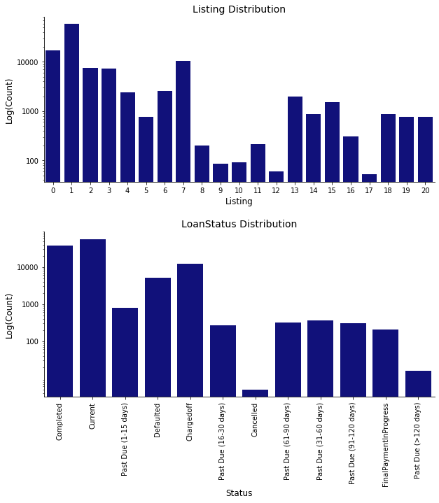

```python
plt.figure(figsize=(10,10))
plt.subplot(2,1,1)
sb.countplot(data=loans, x='ListingCategory (numeric)', color='darkblue');
plt.yscale('log')
plt.yticks([100,1000,10000], ['100', '1000', '10000'])
plt.title('Listing Distribution', fontsize=14)
plt.xlabel('Listing', fontsize=12)
plt.ylabel('Log(Count)', fontsize=12)
plt.subplots_adjust(hspace = 0.3)

plt.subplot(2,1,2)
sb.countplot(data=loans, x='LoanStatus', color='darkblue');
plt.xticks(rotation=90)
plt.yscale('log')
plt.yticks([100,1000,10000], ['100', '1000', '10000'])
plt.title('LoanStatus Distribution', fontsize=14)
plt.ylabel('Log(Count)', fontsize=12)
plt.xlabel('Status', fontsize=12);
sb.despine()
```

> From the barplots,
> - It appears that Debt Consildation (1), Home Improvement (2) and Business (3) are the most popular listings. The dataset also contains lots of 'Not available (0)' and 'Other (7)' listings.
> - Most of the Loans have 'Current' status.

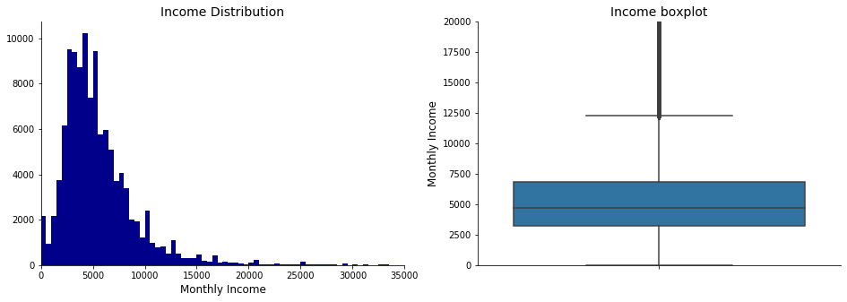

```python
plt.figure(figsize=(16,5))
plt.subplot(1,2,1)
bins = np.arange(0, 100000, 500)
plt.hist(data=loans, x='StatedMonthlyIncome', bins=bins, color='darkblue');
plt.xlim(0, 35000);
plt.title('Income Distribution', fontsize=14)
plt.xlabel('Monthly Income', fontsize=12)

plt.subplot(1,2,2)
sb.boxplot(data=loans, y='StatedMonthlyIncome');
plt.title('Income boxplot', fontsize=14)
plt.ylim(0, 20000)
plt.ylabel('Monthly Income', fontsize=12);
sb.despine()
```

> From MonthlyIncome Plots,
> - It appears that the monthly income distribution is a right-skewed distribution with mean near 5000.
> - There are also a lot of outliers according to the boxplot which needs more investigating.

```python
# Reduce outliers of Monthly Income
print(100*loans[loans['StatedMonthlyIncome']>15000].shape[0] / loans.shape[0])
loans = loans[loans['StatedMonthlyIncome']<=15000]
```

```
2.4220450874359156
```

> **Note: After reducing outliers**

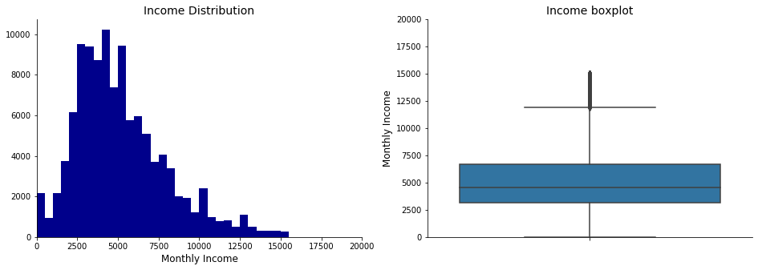

```python
plt.figure(figsize=(16,5))
plt.subplot(1,2,1)
bins = np.arange(0, 100000, 500)
plt.hist(data=loans, x='StatedMonthlyIncome', bins=bins, color='darkblue');
plt.xlim(0, 20000);
plt.title('Income Distribution', fontsize=14)
plt.xlabel('Monthly Income', fontsize=12)

plt.subplot(1,2,2)
sb.boxplot(data=loans, y='StatedMonthlyIncome');
plt.title('Income boxplot', fontsize=14)
plt.ylim(0, 20000)
plt.ylabel('Monthly Income', fontsize=12);
sb.despine()
```

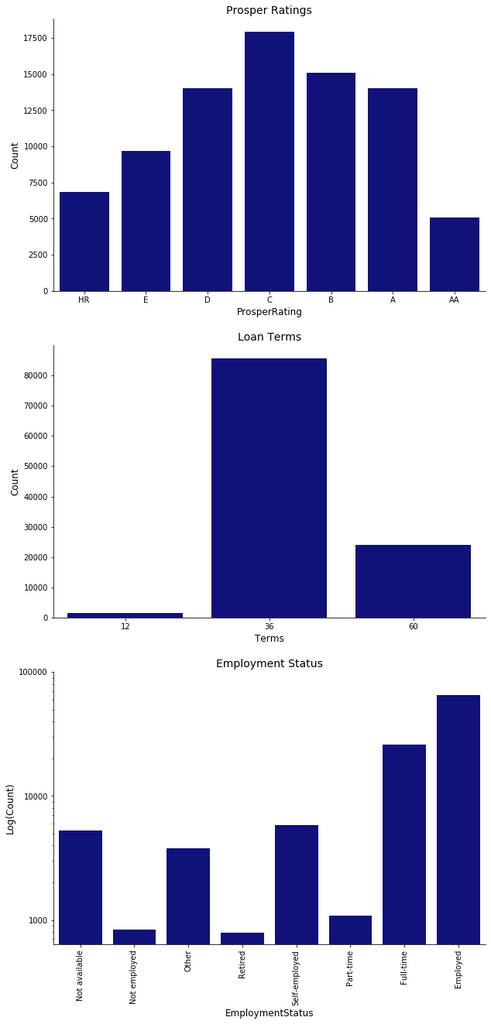

```python
plt.figure(figsize=(10,22))
plt.subplot(3,1,1)
sb.countplot(data=loans, x='ProsperRating (Alpha)', color='darkblue');
plt.title('Prosper Ratings', fontsize=14)
plt.ylabel('Count', fontsize=12)
plt.xlabel('ProsperRating', fontsize=12);

plt.subplot(3,1,2)
# cnt = loans['Term'].value_counts()
# plt.pie(cnt, labels = cnt.index, startangle = 90, counterclock = False, autopct='%1.1f%%');

sb.countplot(data=loans, x='Term', color='darkblue')
plt.title('Loan Terms', fontsize=14)
plt.ylabel('Count', fontsize=12)
plt.xlabel('Terms', fontsize=12);

plt.subplot(3,1,3)
sb.countplot(data=loans, x='EmploymentStatus', color='darkblue');
plt.title('Employment Status', fontsize=14)
plt.ylabel('Log(Count)', fontsize=12)
plt.xlabel('EmploymentStatus', fontsize=12);
plt.yscale('log')
plt.yticks([1000, 10000, 100000], ['1000', '10000', '100000'])
plt.xticks(rotation=90)
sb.despine()
```

> From the above barplot:
> - A, B, C and D are the most popular ratings.
> - It appears that most borrowers are employed and full-time. In addition to that, there is a small portion of the borrowers who are retired or unemployed.
> - The length of most of the loans are 36 months.

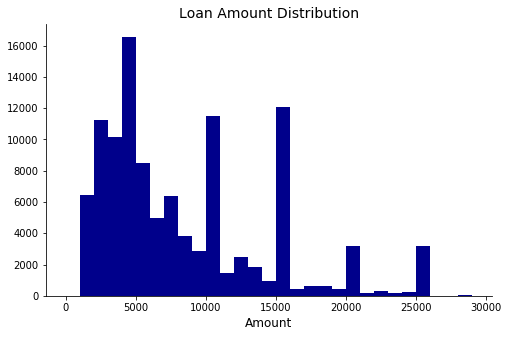

```python
plt.figure(figsize=(8,5))
bins = np.arange(0, 30000, 1000)
plt.hist(data=loans, x='LoanOriginalAmount', bins=bins, color='darkblue')
plt.title('Loan Amount Distribution', fontsize=14)
plt.xlabel('Amount', fontsize=12);
sb.despine()
```

> From the above histogram, I see that borrowers rarely ask for high-amount loans and the distribution is kinda right-skewed.

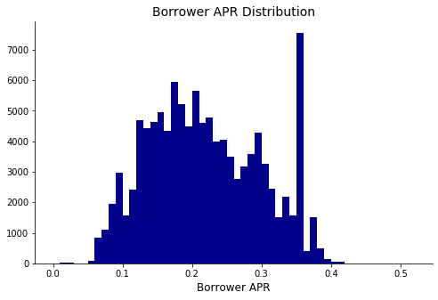

```python
plt.figure(figsize=(8, 5))
bins = np.arange(0, loans.BorrowerAPR.max()+0.01, 0.01)
plt.hist(data=loans, x='BorrowerAPR', bins=bins, color='darkblue');
plt.title('Borrower APR Distribution', fontsize=14)
plt.xlabel('Borrower APR', fontsize=12);
sb.despine()
```

```python
loans.query('BorrowerAPR>0.4').head()
loans.query('BorrowerAPR>0.4').describe()
```

|  | Term | BorrowerAPR | ProsperScore | ListingCategory (numeric) | StatedMonthlyIncome | LoanOriginalAmount | MonthlyLoanPayment |
| --- | --- | --- | --- | --- | --- | --- | --- |
| count | 102.0 | 102.000000 | 74.000000 | 102.000000 | 102.000000 | 102.000000 | 102.000000 |
| mean | 36.0 | 0.414086 | 3.837838 | 3.607843 | 3808.358660 | 1203.323529 | 51.529216 |
| std | 0.0 | 0.018340 | 1.424127 | 2.915160 | 2310.649064 | 664.542531 | 37.634169 |
| min | 36.0 | 0.400230 | 1.000000 | 0.000000 | 0.000000 | 1000.000000 | 0.000000 |
| 25% | 36.0 | 0.406790 | 3.000000 | 1.000000 | 2370.833333 | 1000.000000 | 45.240000 |
| 50% | 36.0 | 0.413550 | 4.000000 | 2.000000 | 3333.333333 | 1000.000000 | 45.240000 |
| 75% | 36.0 | 0.413550 | 5.000000 | 7.000000 | 4895.833333 | 1100.000000 | 48.770000 |
| max | 36.0 | 0.512290 | 6.000000 | 7.000000 | 10833.333333 | 5000.000000 | 240.550000 |

### Of the features you investigated, were there any unusual distributions? Did you perform any operations on the data to tidy, adjust, or change the form of the data? If so, why did you do this?

> - For MonthlyIncome distribution, It was right-skewed with many outliers, some had large income amounts compared to the rest of the borrowers which can be made up, and thus I removed most of them since they represented around 2.5% of the data.
> - For some of the count plots, I used log of count trying to close the gap between numbers since very large numbers can dominate the plot.

## Bivariate Exploration

> In this section, investigate relationships between pairs of variables in your data.

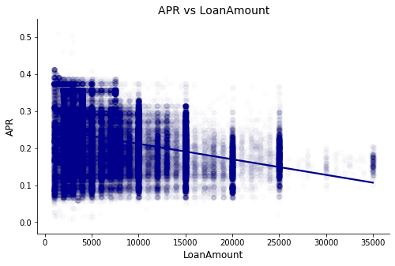

```python
plt.figure(figsize=(8,5))
sb.regplot(data=loans, x='LoanOriginalAmount', y='BorrowerAPR', color='darkblue', x_jitter=100,
          scatter_kws={'alpha':0.01}, fit_reg=True)
plt.title('APR vs LoanAmount', fontsize=14)
plt.xlabel('LoanAmount', fontsize=12)
plt.ylabel('APR', fontsize=12);
sb.despine()
```

> From the above scatter plot, there exists a negative relationship between APR and LoanAmount. The more the loan amount was, the less APR is.

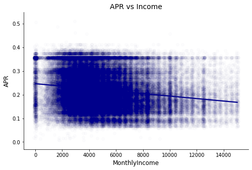

```python
plt.figure(figsize=(8,5))
sb.regplot(data=loans, x='StatedMonthlyIncome', y='BorrowerAPR', color='darkblue', x_jitter=100,
          scatter_kws={'alpha':0.01}, fit_reg=True)
plt.title('APR vs Income', fontsize=14)
plt.xlabel('MonthlyIncome', fontsize=12)
plt.ylabel('APR', fontsize=12);
sb.despine()
```

> From the above plot, it appears that there is a weak negative relation between monthly income and the APR.

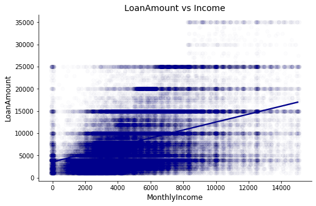

```python
plt.figure(figsize=(8,5))
sb.regplot(data=loans, x='StatedMonthlyIncome', y='LoanOriginalAmount', color='darkblue', x_jitter=100,
          scatter_kws={'alpha':0.01}, fit_reg=True)
plt.title('LoanAmount vs Income', fontsize=14)
plt.xlabel('MonthlyIncome', fontsize=12)
plt.ylabel('LoanAmount', fontsize=12);
sb.despine()
```

> There is a positive relation between loanAmount and Income.

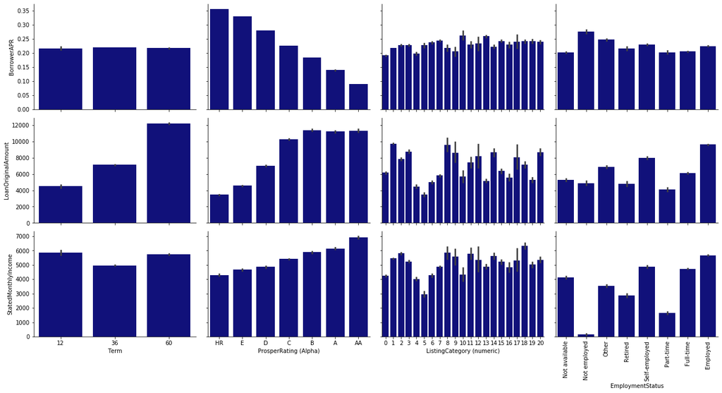

```python
plt.figure(figsize = (10, 10))
g = sb.PairGrid(data=loans, y_vars=['BorrowerAPR', 'LoanOriginalAmount', 'StatedMonthlyIncome'],
                x_vars=['Term', 'ProsperRating (Alpha)', 'ListingCategory (numeric)', 'EmploymentStatus'],
                height=3, aspect = 1.5)
g.map(sb.barplot, color='darkblue')
plt.xticks(rotation=90);
```

> The plots show:
> - Rating has negative relation with APR, the more the rating is, the less APR is.
> - Large loan amounts tend to have longer terms and better ratings.
> - Large loan amounts are mostly created by Employed borrowers.
> - More monthly incomes have higher ratings.

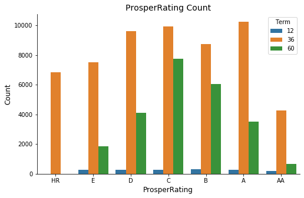

```python
plt.figure(figsize=(8,5))
sb.countplot(data=loans, x='ProsperRating (Alpha)', hue='Term')
plt.title('ProsperRating Count', fontsize=14)
plt.xlabel('ProsperRating', fontsize=12)
plt.ylabel('Count', fontsize=12);
sb.despine()
```

> - HR ratings have only 36-months terms.
> - 36-months ratings is the most popular/standard terms apparently.
> - Most of the 60-months terms tend to have C and B ratings.

### Talk about some of the relationships you observed in this part of the investigation. How did the feature(s) of interest vary with other features in the dataset?

> - The APR has negative relation with LoanAmount. The higher the LoanAmount is, the lower APR is.
> - The APR has negative relation with MonthlyIncome which makes sense since high MonthlyIncome means higher chance to make high loanAmount that correlates negatively with the APR.
> - APR has negative relation with ProsperRatings. The higher the rating is, the lower APR is.

### Did you observe any interesting relationships between the other features (not the main feature(s) of interest)?

> - LoanAmount has positive correlation with MonthlyIncome.
> - LoanAmount has positive correlation with ProsperRatings. High loanAmounts tend to have higher ratings.
> - More MonthlyIncomes have higher ratings.
> - Large loanAmounts are made by employed borrowers.
> - 36-months terms are the most popular across all ratings.
> - Most 60-months terms have C and B ratings.
> - HR ratings have only 36-months terms.

## Multivariate Exploration

> Create plots of three or more variables to investigate your data even further.

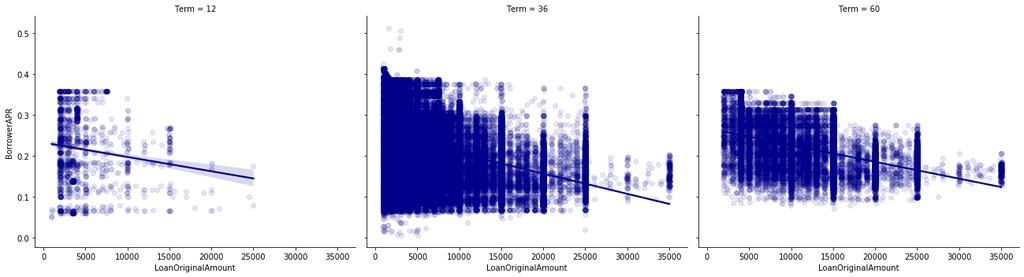

```python
plt.figure(figsize=(10,10))
g=sb.FacetGrid(data=loans, col='Term', col_wrap=4, height=5, aspect=1.2)
g.map(sb.regplot, 'LoanOriginalAmount', 'BorrowerAPR', color='darkblue', x_jitter=100, scatter_kws={'alpha':0.1});
```

> It seems that Term has no effect on the relation between APR and LoanAmount.

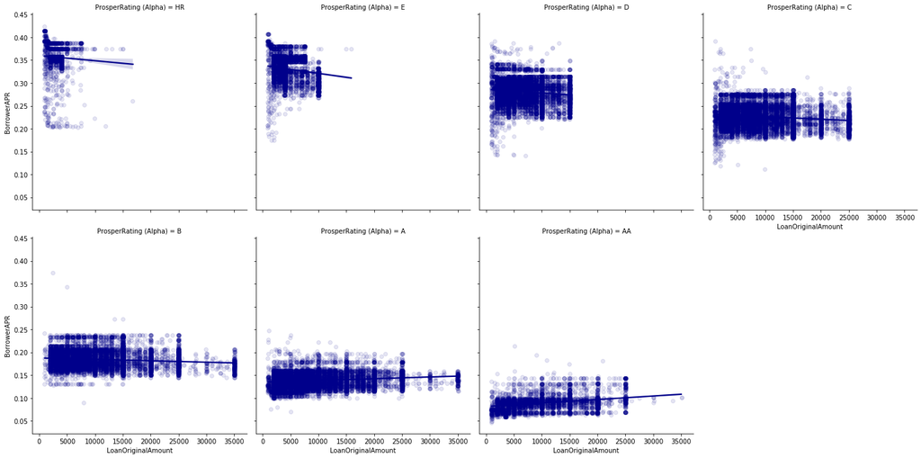

```python
plt.figure(figsize=(10,10))
g=sb.FacetGrid(data=loans, col='ProsperRating (Alpha)', col_wrap=4, height=5, aspect=1)
g.map(sb.regplot, 'LoanOriginalAmount', 'BorrowerAPR', color='darkblue', x_jitter=100, scatter_kws={'alpha':0.1});
```

> - The Negative relation between the APR and loanAmount turns to be slightly positive in high ratings!

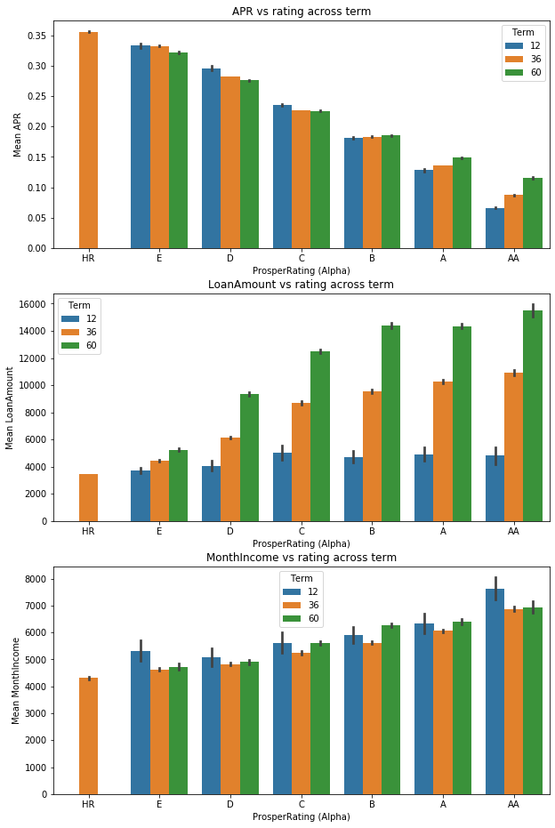

```python
plt.figure(figsize = (10,16))
plt.subplot(3,1,1)
sb.barplot(data=loans, x='ProsperRating (Alpha)', y='BorrowerAPR', hue = 'Term')
plt.title('APR vs rating across term')
plt.ylabel('Mean APR')

plt.subplot(3,1,2)
sb.barplot(data=loans, x='ProsperRating (Alpha)', y='LoanOriginalAmount', hue = 'Term')
plt.title('LoanAmount vs rating across term')
plt.ylabel('Mean LoanAmount')

plt.subplot(3,1,3)
sb.barplot(data=loans, x='ProsperRating (Alpha)', y='StatedMonthlyIncome', hue = 'Term')
plt.title('MonthIncome vs rating across term')
plt.ylabel('Mean MonthIncome');
```

> - There is negative relation between APR and rating across all terms.
> - There is positive relation between LoanAmount and rating for 36-months and 60-months terms but there is no change in 12-months term.
> - For monthly income vs rating, the behaviour across all terms is quite similar with weak positive relation.

### Were there any interesting or surprising interactions between features?

> Yes, APR vs LoanAmount showed a negative relation as expected and as we showed in bivariate plots. However, observing this relation across all ratings, showed this negative relation turning to be slightly positive in higher ratings.